# Analiza danych statystycznych dotyczących sprzedaży gier w latach 2005 - 2016

#### Sprzedaż gier

Rynek gier komputerowych rozwija się bardzo dynamicznie, opracowane dane statystyczne wskazują, że zdecydowanym liderem sprzedaży gier na świecie są kraje Ameryki Północnej, pokrywając prawie 50% światowego zapotrzebowania.

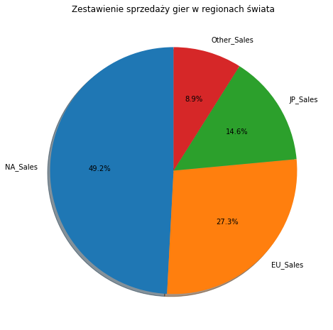

```python
top_region = dg[['NA_Sales', 'EU_Sales', 'JP_Sales', 'Other_Sales']]
top_region = top_region.sum().reset_index()
top_region = top_region.rename(columns={"index": "region", 0: "sprzedaż"})

labels = top_region['region']
sizes = top_region['sprzedaż']
plt.figure(figsize=(10, 8))
plt.pie(sizes, labels=labels, autopct='%1.1f%%', shadow=True, startangle=90)
plt.title("Zestawienie sprzedaży gier w regionach świata")
plt.show()
```

Dane dotyczące konsol na które tworzone są gry, ewidentnie wskazują na duża przewagę PlayStation nad konkurencją. Taki stan rzeczy jest wynikiem bardzo długiej obecności tej konsoli na rynku, w tym czasie PlayStation zbudowało solidną renomę, dostarczając swoim odbiorcom ekskluzywne gry niedostępne na innych platformach w konkurencyjnych cenach.

[figure not shown]

```python
ax = plt.figure(figsize=(15,6))
dg.groupby(['Platform'])['Global_Sales'].sum().plot().bar(15, 10)
plt.xticks(rotation=45)
plt.ylabel('Sprzedaż mln')
plt.title('Wykres sprzedaży gier na poszczególne platformy')
plt.show()
```

Poniżej opracowane zostały wyniki dotycznące sprzedaży poszczególnych gatunków gier w badanych regionach. Łatwo zauważyć, że w krajach Europy i Ameryki Północnej rozkład wyglądą niemalże identycznie. Znaczna różnica pojawia się w zestawieniu tych regionów z Japonią. Bardzo popularne shootery na rynku Japońskim stanowią zaledwie mały ułamek w porównaniu z Europejskim i Amerykańskim, za to dużym zainteresowaniem wyróżniają się gry typu roole-playing. Z całą pewnością można stwierdzić, że jest to wynikiem różnic kulturowych, oraz podejścia społeczności Azjatyckiej do gier w których pojawia sie przemoc.

[figure not shown]

```python
ax1=plt.figure(figsize=(15,6))
sns.barplot(x='Genre', y='NA_Sales', data=dg , palette='Paired')
plt.ylabel("Sprzedaż mln")
plt.title("Sprzedaż gatunków gier w Ameryce Północnej")
plt.show()
```

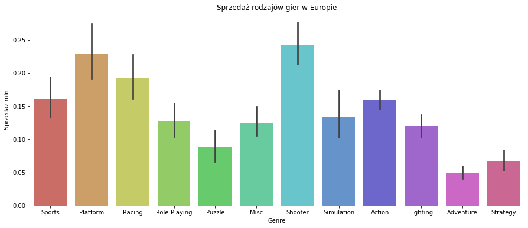

```python
ax2=plt.figure(figsize=(15,6))
sns.barplot(x='Genre', y='EU_Sales', data=dg , palette='hls')
plt.ylabel("Sprzedaż mln")
plt.title("Sprzedaż rodzajów gier w Europie")
plt.show()
```

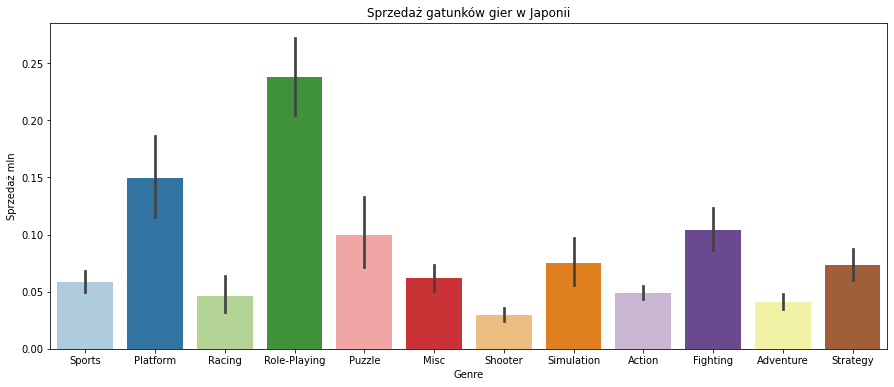

```python
ax3=plt.figure(figsize=(15,6))
sns.barplot(x='Genre', y='JP_Sales', data=dg , palette='Paired')
plt.ylabel("Sprzedaż mln")
plt.title("Sprzedaż gatunków gier w Japonii")
plt.show()
```

### Podsumowanie analizy

Analizowane dane pokazują jak duży i zróżnicowany jest światowy rynek gier. Sczególny wpływ na zainteresowanie tą dziedziną ma rywalizacja w świecie konsol. Lata 2007-2010 były przełomowe w rozwoju rynku gier, odnotowany został wtedy największy przyrost zainteresowania konsolami oraz grami. Od tamtego czasu cała branża prężnie i stabilnie się rozwija, przewidywania na rok 2022 wskazują, że wartość rynku przekroczy 50 miliardów dolarów.